# Zamboni et al (2016)

Data analysis and model fitting of behavioural data in Julia. Accompanies the manuscript

> *Do perceptual biases emerge early or late in visual processing?*

> Elisa Zamboni, Timothy Ledgeway, Paul V McGraw & Denis Schluppeck

> School of Psychology, University of Nottingham University Park, Nottingham, NG7 2RD, UK

For a list of references and related publications from other labs, please refer to the manuscript of the paper.

## General comments

A standard install of Julia (http://www.julialang.org) with some packages (all in METADATA) is required: in particular **PyPlot** (for generating some nice plots) **Distributions** (for allowing the use some distributions to describe the weighting profile).

The `Pkg.add("Distributions")` and other calls should only be required the first time you run this.

You may also want to consider running the notebook on **JuliaBox** (http://www.juliabox.org).

## Versions / testing

The code included below was run locally, tested with Julia v0.4.2 and v0.4.3, IJulia, PyPlot and Optim.

If you find problems with any of the code, or bugs, please open an issue or send a pull request.

https://github.com/schluppeck/zamboni-2016/issues

## Description of the late decision-related bias model

### Components

The has three main components:

1. the **sensory representation of the visual stimulus** which is carried through all the way to a decision stage. In the code below, this is labelled `S`. The sensory representation is modelled as a Gaussian distribution (in direction space); the variance for this (the main parameter of interest) can be obtained by fitting a cumulative Gaussian distribution function to the data from the discrimination task. Alternatively, it can be included as an additional parameter in the model fitting procedure. The distribution is centred on the direction of motion of the visual stimulus.
2. a **weighting profile**, `W`, that applies repulsive shifts from applied to the sensory representation, `S`. In our implementation, the weighting function represents a late, decision-related bias. The specific shape of the function (and the fact that it is bimodal) captures both a repulsion away from the reference line, as well as the (attractive) influence of the boundary imposed by the stimulus range. Possible choices for such a function are the Gamma distribution or any other parametric curve that has a similar shape. The asymmetric nature of the Gamma function n particular (steeper close to the reference) reflects the fact that the boundary of the stimulus range, which the subject learns over time, is noisier.
3. **information about whether a reference is present** or absent at the time of estimtation. If yes, then the weighting can be applied as the reference repulsion can be anchored to a particular direction. If no, then an (on average) uniform weighting is applied. This can be thought of as either *no weighting* or a *uniform random* weighting over many trials.

The inputs to the model are, for a number of trials, the stimulus direction, the subject's estimate, and whether the reference was present, absent or shifted.

The weighting function is modelled as a **Gamma probability density function** defined by the free parameters shape (A) and scale (B). In addition, a parameter δ describes any change in the location of the reference line from the discrimination to the estimation task phase. Also, the weighting (repulsive shift) is only applied if a reference is present at the estimation stage. These additional parameters are necessary because in our model, the repulsive shifts apply only at a late, decision-related stage and only if a reference was present.

An alternative weighting function (which has a similar shape to the Gamma function) is a difference of gaussians. Using this also provides a reasonable fit to the data.

Step through the notebook to run the model fitting for one particular data set. Only small modifications are needed to run the model fitting for the complete data set automatically.

## Initialize packages

You may need to "install" the appropriate packages if you haven't already. Run the following lines to do this and the packages will be installed in your `~./julia` folder

```
Pkg.add("PyPlot")
Pkg.add("Distributions")
Pkg.add("LsqFit")
```

```julia
# include packages for use here
using PyPlot
using Distributions
using LsqFit
using Optim
using Base.Markdown
```

## Load data from files

Data files are provided as comma-separated files. The conventions for the data files included with this code are:

```
subject[ID]-reference-[absent|present|shifted].csv
subjectA-reference-absent.csv
```

Each row contains a trial. For present|absent data, there are 3 columns

1. (true) stimulus direction
2. estimated direction
3. coherence levels:

For the data obtained in the "shifted" condition, there are 4 columns

1. (true) stimulus direction
2. estimated direction
3. shift (-6º, 0º, +6º)
4. coherence levels

```julia
# decide which file to load
#
filename = "subjectD-reference-present.csv";

# check data from which experiment:
#
if contains(filename, "reference-absent")
    experiment = "absent"
elseif contains(filename, "reference-present")
    experiment = "present"
elseif contains(filename, "reference-shift")
    experiment = "shifted"
else
    error("! not sure how to deal with these data files")
end

# decide which part of the data set to select for fitting:
#
coherenceCondition = 1; # 2, 3, 4 : coherence = 0.04, 0.07, 0.13, 0.25
shiftCondition = 3; # 2, 3 : shift = -6º, 0º or 6º

# reading tab, comma delimited files can be done as follows
data = readdlm(filename, ',', Float64, skipstart=2);


if experiment == "present" || experiment == "absent"
    # for present|absent data, b has 3 columns
    #
    # 1. (true) stimulus direction
    # 2. estimated direction
    # 3. coherence levels:

    coherenceLevels = unique(data[:,3]);
    coherence = coherenceLevels[coherenceCondition];

    # select out those trials
    # b for "behavioural data"
    b = data[ data[:,3] .== coherence, :];

elseif experiment == "shifted"
    # for shifted data, b has 4 columns
    #
    # 1. (true) stimulus direction
    # 2. estimated direction
    # 3. shift (-6º, 0º, +6º)
    # 4. coherence levels

    # select out those trials, but also for a particular shift condition:
    # for the data in which we change the reference:
    referenceShifts = unique(data[:,3]);
    theShift = referenceShifts[shiftCondition];

    coherenceLevels = unique(data[:,4]);
    coherence = coherenceLevels[coherenceCondition];

    # logical index for correct shift trials at the chosen coherence level
    idx = (data[:,3] .== theShift) & (data[:,4] .== coherence);
    b = data[idx, :];
    b = sortrows(b);
end


println("In this experiment the reference at esimation was: ", experiment);
println("\n**Coherence**")
println("The coherence levels in this experiment were: ", coherenceLevels);

println("\n**Stimulus**")
println("Stimulus condition = ", coherenceCondition, ". We are analyzing data with c=", coherence);

if experiment == "shifted"
    println("Shift condition = ", shiftCondition, ". We are analyzing data with shift=", theShift, " degrees");
end
```

```
In this experiment the reference at esimation was: present

**Coherence**
The coherence levels in this experiment were: [0.04,0.07,0.13,0.25]

**Stimulus**
Stimulus condition = 1. We are analyzing data with c=0.04
```

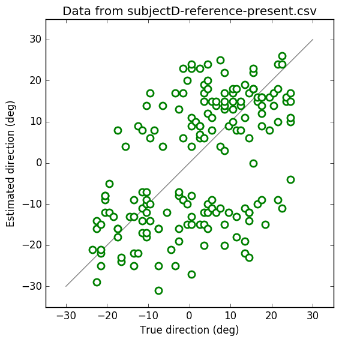

```julia
# Scatter plot of trials
plot([-30; 30],[-30; 30], "-", color="gray")
plot(b[:,1], b[:,2], "bo", ms=8, mfc="white", mec="green", mew=2);

axis("square")
axis([-35; 35; -35; 35])
xlabel("True direction (deg)");
ylabel("Estimated direction (deg)");
title("Data from $filename");
```

```julia
# turn this into a simple plotting function
# to save repeated typing.
function plotData(pts)
    dirRange = 35;
    plot(dirRange.*[-1; 1],dirRange.*[-1; 1], "-", color="gray")
    plot(pts[:,1], pts[:,2], "bo", ms=8, mfc="white", mec="green", mew=2);
    xlabel("True direction (deg)");
    ylabel("Estimated direction (deg)");
    axis("square")
    axis(dirRange.*[-1; +1; -1; +1])
    title("Data from $filename");
end
```

```
plotData (generic function with 1 method)
```

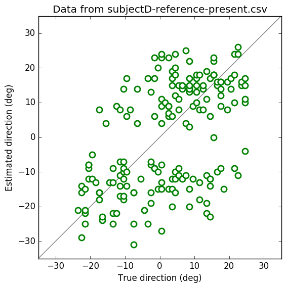

```julia
# make a figure using the plotting function
f_ = figure();
plotData(b);
```

## Saving plots to files

Use the following convention to save data of PDF format (or change to JPG, PNG) if preferred.

```julia
# this is how to save the current figure out to a file. The ending determines the format.
# you can also try .png or .jpg
# ?PyPlot  for more help at the Julia prompt
outFilename = replace(filename, ".csv", "-scatter.pdf")
f_[:savefig](outFilename)
```

## The model

Let's build up the model by implementing one component after another.

1. Sensory representation, `S`, veridical stimulus information.
2. weighting function, `W`, repulsive effect (w/ given profile, if reference is present, constant otherwise)
3. biased response (W .* S). This model also makes predictions for "incorrect trials", i.e. trials in which the subject's response is biased away from veridical, but with the opposite sign.

## Making, S, the sensory representation

```julia
modelGrain=1.0; # in degrees; the modelGrain controls how finely spaced the model calculations are
# 1 (deg) is more precise, but slower

d = collect(-180.0:modelGrain:180.0); # a vector; directions for sensory space

# repackage data into variables that are more meaningful when we read them...
trueDirections = b[:,1]; # first column of behavioural data is the TRUE directions
perceivedDirections = b[:,2];

# the sigma (std) of the sensory representation (PP for PsychoPhysics)
# this can be a free parameter (or estimated from psychmetric data in binary choice data)
σ_PP = 15; # for example;

# set the random seed for "Distributions"
srand(123);


"""
Make the sensory representation for many different true directions at the same time.

This version of the model implements the shortcut of using the distributions of mean internal
representationsnTrials, rather than using randomly sampled trials.

"""
function getSensoryRepresentation(trueDirections, d, σ_PP=20, nTrials=1)

    i = 0; # a counter
    S = zeros(length(d),length(trueDirections),nTrials)
    for μ in trueDirections
        i = i+1;
        # set up the distribution for this set of trials "thisDistribution"
        thisDistribution = Normal(μ, σ_PP );
        if nTrials == 1
            # then just calculate the mean internal representation
            S[:,i] = pdf(thisDistribution, d);

        elseif nTrials > 1
            # then just calculate the internal representation for nTrials different trials
            for iTrial = 1:nTrials
                thisMu = rand(thisDistribution, 1);
                S[:,i,iTrial] = pdf(Normal(thisMu[1], σ_PP), d);
            end
        end
    end
    return S

end

# get an instance for a particular set of trueDirections / σ / and number of trials
σ = 20.0;
S_1 = getSensoryRepresentation(trueDirections, d, σ, 1);
S_10 = getSensoryRepresentation(trueDirections, d, σ, 10);
```

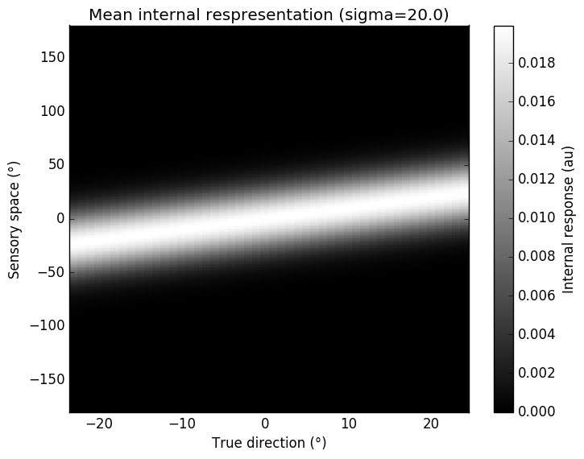

```julia
# we can represent this as an image...
tf_ = figure();

pcolor(trueDirections,d, S_1[:,:,1]);
gray(); # use gray scale to show this...
cb_ = colorbar();
axis("tight");
xlabel("True direction (°)");
ylabel("Sensory space (°)");
cb_["set_label"]("Internal response (au)");
title("Mean internal respresentation (\sigma=$σ)");

tf_[:savefig]("sensoryRepresentation.pdf")
```

## Making, W, the weighting function

The cell below shows how the weighting function is constructed. We use a gamma function (similar to that used by Jazayeri & Movshon, 2007), but other curves with a similar profiles can be used to result in the perceptual biases.

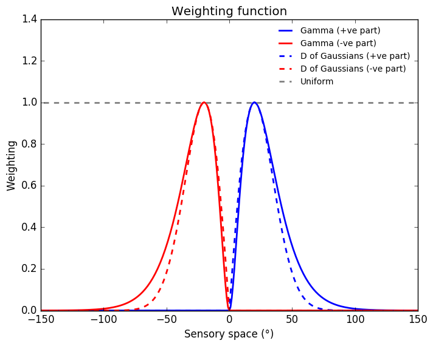

```julia
# now try out the weighting function that applies the repulsive bias
# W is calculated like this
W = pdf(Gamma(3,10 ), d);
W = W./maximum(W); # normalize to height 1

# it could be something else, too e.g. "difference of gaussians..."
W_dog = max(pdf(Normal(+1,20 ), d) - pdf(Normal(-1,20 ), d), 0.0);
W_dog = W_dog./maximum(W_dog);

wf_ = figure();
plot(d, W ,"b", lw=2, label="Gamma (+ve part)");
hold(true);
plot(-d, W, "r",lw=2,label="Gamma (-ve part)");

# difference of gaussians
plot(d, W_dog, "b--",lw=2, label="D of Gaussians (+ve part)");
plot(-d, W_dog, "r--",lw=2, label="D of Gaussians (-ve part)");

# uniform
plot(d, ones(d), color="gray", ls="--", lw=2, label="Uniform");


legend(frameon=false, fontsize="small")


axis([-150, 150, 0, 1.4]);
title("Weighting function");
xlabel("Sensory space (°)");
ylabel("Weighting");

wf_[:savefig]("weightingFunctions.pdf")
```

```julia
# set up a function for the weighting
"calculate the weighting function (Gamma, or DOG)"
function getWeighting(p, d, kind="gamma")

    if (lowercase(kind) == "gamma") || (lowercase(kind) == "gamma+shift")
        # gamma or gamma+shift
        # use a gamma function, which has to parameters.
        # the gamma function is only defined for d > 0
        # so we can flip the axis and create the other lobe
        Wpos = pdf(Gamma(p[1],p[2] ), d);
        Wneg = pdf(Gamma(p[1],p[2] ), -d);


    elseif lowercase(kind) == "dog"
        # use a difference of gaussians
        Wpos = max(pdf(Normal(+1,20 ), d) - pdf(Normal(-1,20 ), d), 0.0);
        Wneg = max(pdf(Normal(-1,20 ), d) - pdf(Normal(+1,20 ), d), 0.0);


    elseif lowercase(kind) == "uniform"
        # and uniform profile.
        Wpos = max(sign(d),0);
        Wneg = max(sign(-d),0);
    end

    # in this implementation of the model, we want both lobes.
    W = Wpos + Wneg;
    scaleFac = maximum(W);

    return (W./scaleFac, Wpos./scaleFac, Wneg./scaleFac)
end
```

```
getWeighting (generic function with 2 methods)
```

```julia
# set up a function for model
# by defining d, dEdges which are constant while fitting first, we avoid unnecessary allocations.
# the Weighting function W and sensory representations change during model fitting (they depend on the parameters),
# so we can't use this trick.

dEdges = collect(-50:modelGrain:50);

# need to work on the centers of this
d = 0.5.*(dEdges[1:end-1] + dEdges[2:end]);

if experiment == "present"
    weightingFunction = "gamma"; # or dog
    params0 = [4.0; 6.0; 15]; # X0 = [A, B, σ] for optimization
elseif experiment == "shifted"
    weightingFunction = "gamma+shift"
    params0 = [4.0; 6.0; 0.0; 15]; # X0 = [A, B, δ, σ] for optimization
elseif experiment == "absent"
    weightingFunction = "uniform"
    params0 = [NaN; 15]; # X0 = [σ] for optimization
end


"calculate the model for a given set of stimulus directions and weighting function parameters, p "
function modelFunction(trueDirections, p, weightingFunction)

    # get the weighting function
    (W, Wpos, Wneg) = getWeighting(p,d, weightingFunction);

    # get the sensory representation
    S = getSensoryRepresentation(trueDirections, d, p[end], 1);
    S = squeeze(S,3);

    i = 0;
    modelFit = zeros(length(trueDirections),2);
    WSRpos = zeros(S);
    WSRneg = zeros(S);

    # loop through each "column" of the dataset (for each stimulus direction...)
    for μ in trueDirections
        i = i+1;
        WSRpos[:,i] = Wpos .* S[:,i];
        WSRneg[:,i] = Wneg .* S[:,i];

        idxPos = indmax(WSRpos[:,i]); ; # find max of element-wise multiply
        idxNeg = indmax(WSRneg[:,i]); ; # find max of element-wise multiply

        modelFit[i,1] = d[idxPos]
        modelFit[i,2] = d[idxNeg]
    end

    if weightingFunction == "gamma+shift"
        # then we also need to deal with the shift parameter for the prediction
        modelFit = modelFit .+ p[3];
    end

    WSR = WSRpos + WSRneg;

    return ( modelFit, WSR, WSRpos, WSRneg)
end

"Fitting function needs to only take x,p and return modelfit values"
function fittingFunction(tt, p)
    v,w,s = modelFunction(tt, p, weightingFunction)  ;
    return v
end
```

```
fittingFunction (generic function with 1 method)
```

```julia
# make a broken plot function (that shows x <=0 then again for X >0)

"plots the data for negative and positive y values separately, split at 0"
function fitPlot(x, y)
    # predictions within one step (modelGrain) of 0 could be replaced with NaNs.
    # We just don't plot them in this version.
    validIdx = abs(y) .> modelGrain;

    # prepare to plot +ve and -ve estimates / parts of the fit separately
    negativeIdx = (y .< 0.0) & validIdx;
    positiveIdx = (y .> 0.0) & validIdx;

    plot(x[negativeIdx], y[negativeIdx], "b-", lw=3);
    hold(true)
    plot(x[positiveIdx], y[positiveIdx], "b-", lw=3);
end
```

```
fitPlot (generic function with 1 method)
```

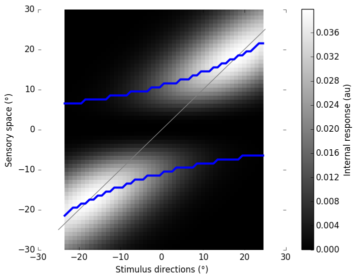

```julia
# try out the model function for some true directions, given the params [2,4.1]
T = sort(trueDirections);

if experiment == "shifted"
    values, WSR, WSRpos, WSRneg = modelFunction(T, [5, 4, 0, 12],"gamma+shift");
elseif experiment == "present"
    # if we want this for a different weighting function, this would be
    values, WSR, WSRpos, WSRneg = modelFunction(T, [4.0, 6.0 ,10], "gamma");
elseif experiment == "absent"
    # if we want this for yet another  weighting function, this would be
    values, WSR, WSRpos, WSRneg = modelFunction(T, [10], "uniform");
    # only one parameter matters: the σ of the internal sensory representation
end

figure(),
pcolor(T,d, WSR);
gray(); # use gray scale to show this...
cb_ = colorbar();
axis("tight");
xlabel("Stimulus directions (°)");
ylabel("Sensory space (°)");
cb_["set_label"]("Internal response (au)");
axis([-30, 30, -30, 30]);
box(false);
hold(true);
plot([-25; 25], [-25; 25], "-", color="gray")
# plot the fits for positive and negative estimates separately
fitPlot(T, values[:,1]);
fitPlot(T, values[:,2]);
```

```julia
# make sure we fit data data by considering the centres of the joint histograms (not the edges)
trueDirectionsCenters = 0.5 .* (trueDirections[1:end-1] + trueDirections[2:end]);

# a function that returns the error between the data and the model
# closure: perceivedDirections is already present

" Calculate the sum of squared errors between data points and the model prediction"
function sqerror(params)
    cumulativeErr = 0.0
    thisErr = 0.0
    for ii in 1:length(trueDirectionsCenters)
        pred_i = fittingFunction(trueDirectionsCenters[ii], params);
        # there are two predictions (one for estimates reported CCW to reference: -ve, another +ve)
        thisErr = (perceivedDirections[ii] - pred_i).^2;
        # take the smaller error (the prediction of the two that is closer to the data point)
        cumulativeErr += minimum(thisErr);
    end
    return cumulativeErr
end
```

```
sqerror (generic function with 1 method)
```

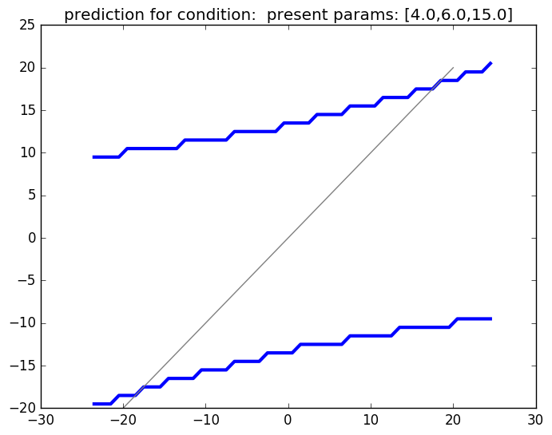

```julia
# a prediction for a particular set of paramters would be, e.g.
if (experiment == "present") || (experiment  == "shifted")
    pred_i = fittingFunction(T, params0);
    titlestr = join(["prediction for condition: ", experiment, "params: $params0" ], " ")
elseif experiment  == "absent"
    pred_i, u,v,b = modelFunction(T, [12.0], "uniform");
    titlestr = join(["prediction for condition: ", experiment, ", \sigma: 12.0" ], " ")
end

figure();
fitPlot(T, pred_i[:,1]);
hold(true)
fitPlot(T, pred_i[:,2]);
plot([-20; 20], [-20, 20], "-", color="gray");
title(titlestr);
```

```julia
# Now run the actual optimization:
if experiment == "absent"
    # in this case we don't need to fit the model; the sensory representation (veridical)
    # translates through to unbiases responsed.
    # the σ corresponds to the standard deviation of estimates
    resultParams = std(perceivedDirections-trueDirections)
    #modelFunction(trueDirections, , weightingFunction)

else
    # do the optimization and plot the result
    # "present", shifted"
    fitValue = optimize(sqerror, params0)
    resultParams = fitValue.minimum;
    println("The fit values from the optimization are ", resultParams)

end
```

```
The fit values from the optimization are [3.573143067001623,6.321724749263126,16.085068610300407]
```

```julia
# the standard deviation of all the estimates (relative to the actual direction)
# for the "reference absent" condition, there is no need to run the non-linear optimization, as
# the resulting σ in the model is straightforwardly related to the data:
#
std(trueDirections - perceivedDirections)
```

```
14.223600034563995
```

## Plot the results

Provide a summary plot that shows:

1. in gray scale, the sensory representation with repulsive shift / weighting applied (if applicable)
2. the data, symbols (estimated responses for different stimulus directions)
3. the model fit, solid coloured line
4. the line of unity, thin gray line, indicating where veridical responses should fall

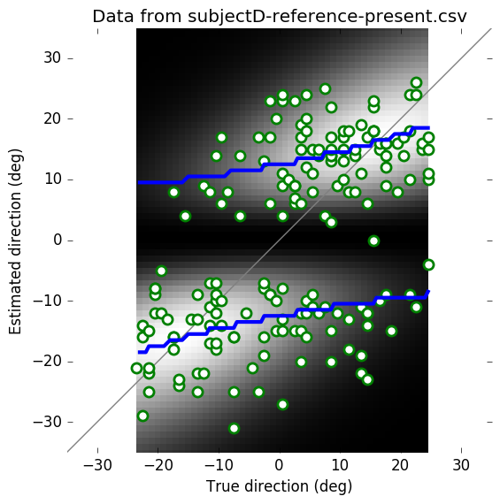

```julia
( fitResult, WSR, WSRpos, WSRneg) = modelFunction(trueDirectionsCenters, resultParams, weightingFunction)
fitFigure_ = figure()
pcolor(T,d, WSR);
hold(true)
plotData([trueDirections perceivedDirections])
fitPlot(trueDirectionsCenters, fitResult[:,1]);
fitPlot(trueDirectionsCenters, fitResult[:,2]);
box("off")
fitFilename = replace(filename, ".csv", "-data-with-fit.pdf")
fitFigure_[:savefig](fitFilename)
```